# Animal Crossing Data

# Escaping the Real World to Run Errands in a Virtual Game

With the world currently in quarantine, many people are finding a way to kill time with Nintendo’s latest release: “Animal Crossing: New Horizons”!

In this game, players escape to a deserted island where they become indebted to Tom Nook, a tanuki capitalist overlord who holds all of your mortgages. It is up to the player to run errands and collect items such as fruit, insects and fish to sell to the tanuki in hopes of ever repaying their debt and earning new upgrades to make the island more beautiful. In this game, you are in control of the island and have the ability to design and decorate it in any way you like! You can also socialize with villagers who can give you new crafting recipes (to make cool furniture or items for your house or for the island) and gifts if you befriend them, or you can be mean and force them to leave the island if you don’t like their personality.

As you might have figured out by now, this blog will be focusing on Animal Crossing data!

The data set we found on TidyTuesday has 4 different tables: Items, Villagers, Critic Reviews, and User Reviews. In this blog, we will explore these data table and answer see what we can discover from each table.

Let’s start of with the Items data!

## Items

In Animal Crossing, there are many different items in the game. But for the purpose of this blog and to make our lives easier, we will be focusing on the items that are categorized as furniture.

Here, we will filter out the table to focus on furniture sets and find out which furniture sets are the cheapest and most expensive to purchase in the game.

**Cheapest Furniture Sets**

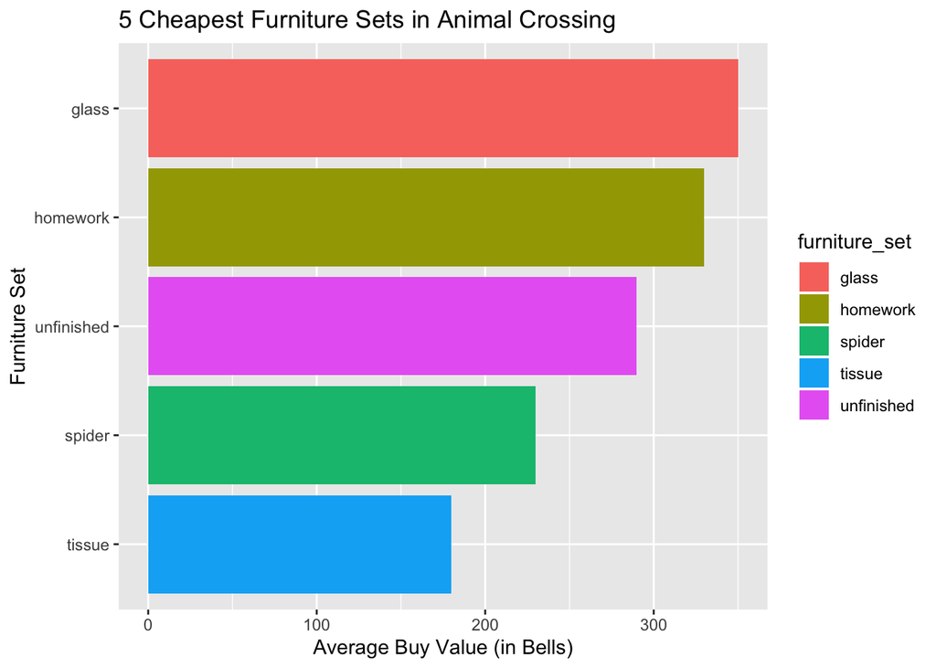

```r
cheap_furniture_items = items %>%
  filter(category == "Furniture") %>%
  select(num_id, id, name, sell_value, buy_value) %>%
  mutate(furniture_set = str_extract(id, ".*?-")) %>%
  mutate(furniture_set = gsub("-", "", furniture_set)) %>%
  group_by(furniture_set) %>%
  summarize(mean_buy_value = mean(buy_value, na.rm = TRUE)) %>%
  arrange(desc(mean_buy_value)) %>%
  top_n(-5, mean_buy_value)

ggplot(data = cheap_furniture_items, aes(x = fct_reorder(furniture_set, mean_buy_value), y = mean_buy_value)) +
  geom_col(aes(fill = furniture_set)) +
  coord_flip() +
  labs(title = "5 Cheapest Furniture Sets in Animal Crossing", x = "Furniture Set", y ="Average Buy Value (in Bells)")
```

Looks like the average price of an item in the cheapest furniture sets ranges from 180 to 350 bells! Not too bad for the price, though they probably don’t look that good…

**Most Expensive Furniture Sets**

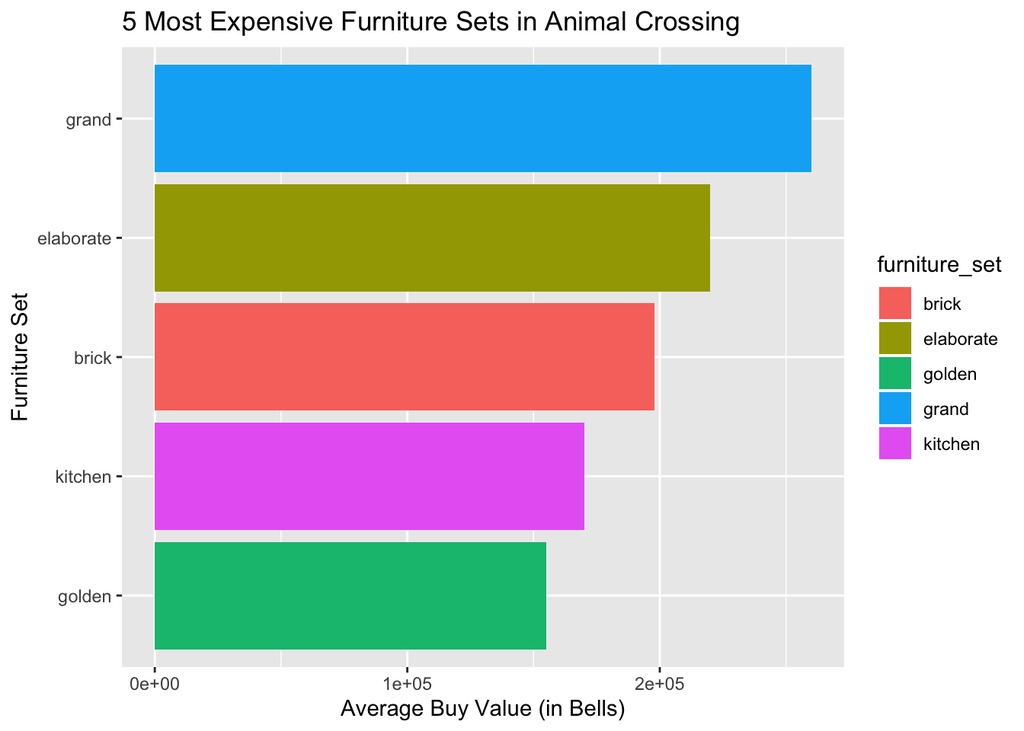

```r
expensive_furniture_items = items %>%
  filter(category == "Furniture") %>%
  select(num_id, id, name, sell_value, buy_value) %>%
  mutate(furniture_set = str_extract(id, ".*?-")) %>%
  mutate(furniture_set = gsub("-", "", furniture_set)) %>%
  group_by(furniture_set) %>%
  summarize(mean_buy_value = mean(buy_value, na.rm = TRUE)) %>%
  arrange(desc(mean_buy_value)) %>%
  top_n(5, mean_buy_value)

ggplot(data = expensive_furniture_items, aes(x = fct_reorder(furniture_set, mean_buy_value), y = mean_buy_value)) +
  geom_col(aes(fill = furniture_set)) +
  coord_flip() +
  labs(title = "5 Most Expensive Furniture Sets in Animal Crossing", x = "Furniture Set", y ="Average Buy Value (in Bells)")
```

Now let’s move on to the villager data!

## Villagers

Villagers in animal crossing are…animals and there are many different types of animals in the game. 35 different species to be exact! Each villager has their own personality which can be categorized into 8 different types (4 female, 4 male): Normal, Peppy, Snooty, Uchi (sisterly), Cranky, Jock, Lazy, and Smug.

Let’s take a look and see if the different personality types are evenly distributed amongst villagers or if there are more common personalities.

**Question: Are there more of a certain type of personality or is it evenly distributed?**

```r
villagers %>%
  count(personality) %>%
  arrange(desc(n))
```

```
## # A tibble: 8 x 2
##   personality     n
##   <chr>       <int>
## 1 lazy           60
## 2 normal         59
## 3 cranky         55
## 4 jock           55
## 5 snooty         55
## 6 peppy          49
## 7 smug           34
## 8 uchi           24
```

Based on the table, there doesn’t seem to be an even distribution of personalities. Let’s take a look at a graph to get a better visualization:

**Creating a graph to show the distribution of personalities**

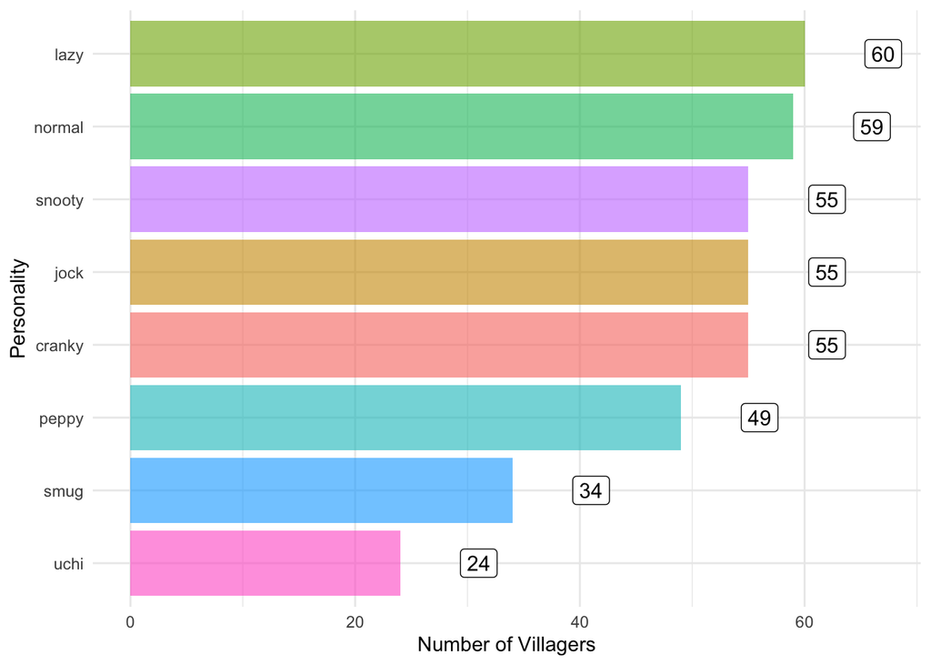

```r
villagers %>%
  count(personality) %>%
  arrange(desc(n)) %>%
  ggplot(aes(x = fct_reorder(personality,n), y = n))+
  geom_col(aes(fill = personality), alpha = 0.6)+
  labs(x = "Personality", y = "Number of Villagers")+
  geom_label(aes(label = n), size = 4, nudge_y = 7) +
  theme_minimal()+
  theme(legend.position = "none")+
  coord_flip()
```

According to the graph, it looks like the most common personality trait is lazy and the least common personality trait is uchi (uchi is a female villager personality. They are very caring and not too vain towards other villagers).

Another thing to notice from the graph is that it appears as though the distribution pattern amongst the personalities for male and female are the same. To see this more clearly, let’s take a look at the same graph but instead have it split betwen male and female:

**female**

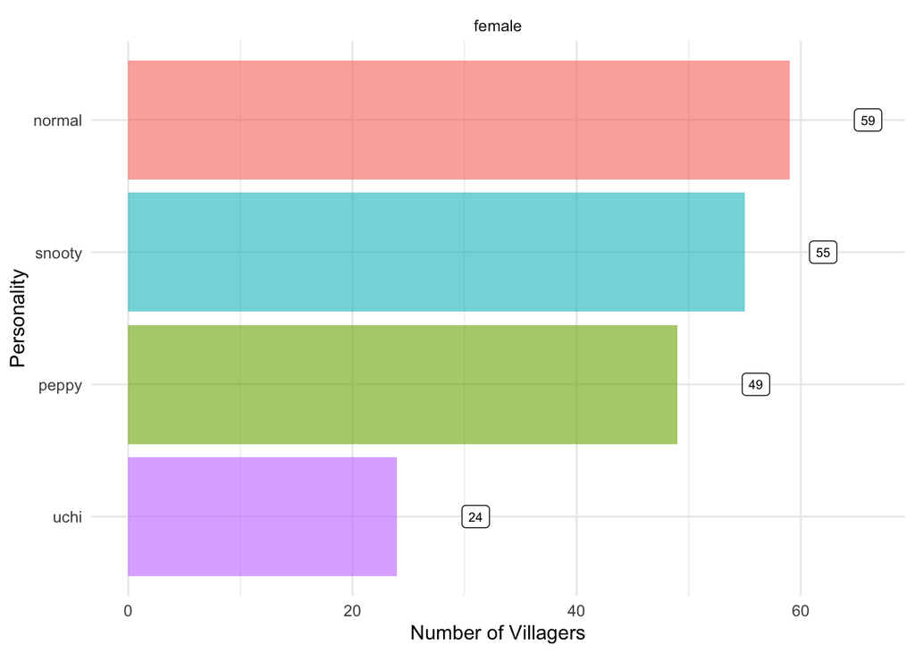

```r
personality_female = villagers %>%
  filter(gender == "female") %>%
  group_by(gender) %>%
  count(personality) %>%
  arrange(desc(n)) %>%
  ggplot(aes(x = fct_reorder(personality, n), y = n))+
  geom_col(aes(fill = personality), alpha = 0.6)+
  labs(x = "Personality", y = "Number of Villagers")+
  geom_label(aes(label = n), size = 2.5, nudge_y = 7) +
  theme_minimal()+
  theme(legend.position = "none")+
  coord_flip()+
  facet_wrap(~gender)

personality_female
```

**male**

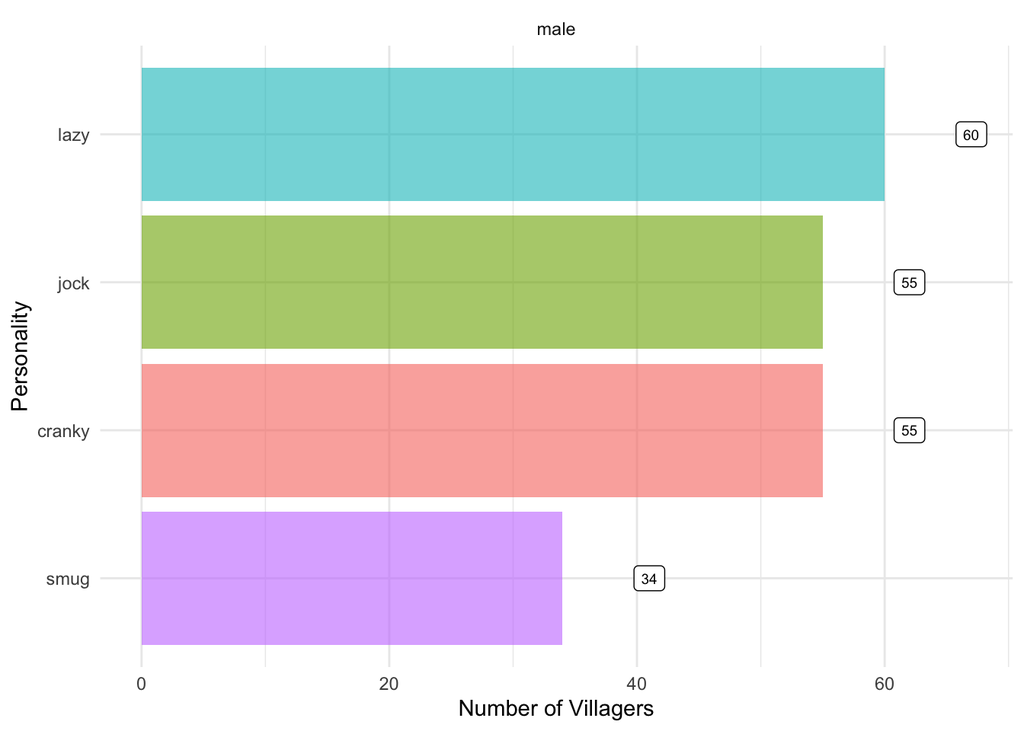

```r
personality_male = villagers %>%
  filter(gender == "male") %>%
  group_by(gender) %>%
  count(personality) %>%
  arrange(desc(n)) %>%
  ggplot(aes(x = fct_reorder(personality, n), y = n))+
  geom_col(aes(fill = personality), alpha = 0.6)+
  labs(x = "Personality", y = "Number of Villagers")+
  geom_label(aes(label = n), size = 2.5, nudge_y = 7) +
  theme_minimal()+
  theme(legend.position = "none")+
  coord_flip()+
  facet_wrap(~gender)

personality_male
```

When you look at the two graphs, you can see how there is always the most common trait, then 2 common traits which arent that far off (in terms of numbers) from the most common trait, and then the least common trait which falls behind by quite a bit.

Therefore, it looks like the chances of meeting a lazy male villager or normal female villager are higher than meeting a smug male villager or uchi female villager.

Now let’s take a look at how the personalities are distributed in each species of animal:

**Question: What is the distribution of personalities amongst different types of animals?**

First let’s take a look at the distribution of species:

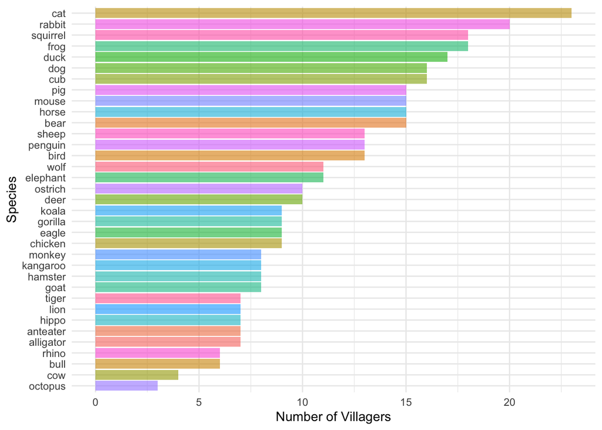

```r
villagers %>%
  count(species) %>%
  arrange(desc(n)) %>%
  ggplot(aes(x = fct_reorder(species,n), y = n))+
  geom_col(aes(fill = species), alpha = 0.6)+
  labs(x = "Species", y = "Number of Villagers")+
  theme_minimal()+
  theme(legend.position = "none")+
  coord_flip()
```

There are 35 different species, and having to look at 35 different graphs can be quite hectic, so to make our lives easier let’s focus on the top 5 animals. The 5 most common animals are: cats, rabbits, squirrels, frogs, and ducks.

First let’s take a look into the personality distribution of the most popular animal: cats!

**Cat Personality**

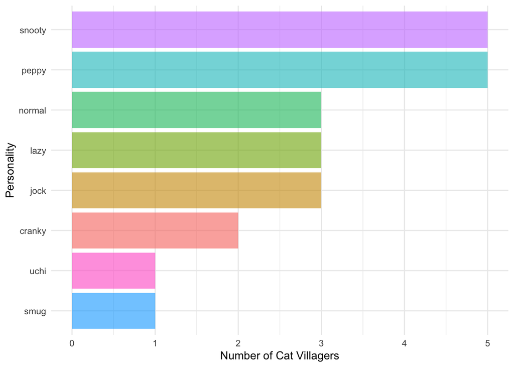

```r
villagers_cats = villagers %>%
  filter(species == "cat") %>%
  count(personality) %>%
  arrange(desc(n)) %>%
  ggplot(aes(x = fct_reorder(personality, n), y = n))+
  geom_col(aes(fill = personality), alpha = 0.6)+
  labs(x = "Personality", y = "Number of Cat Villagers")+
  theme_minimal()+
  theme(legend.position = "none")+
  coord_flip()

villagers_cats
```

Interesting, it seems as though the personality types among the cats is not evenly distributed. Looks like the most common personality traits of cats are snooty and peppy and the least common traits are smug and uchi personalities. I wonder if this is the same for the other animals?

Now let’s take a look at the others:

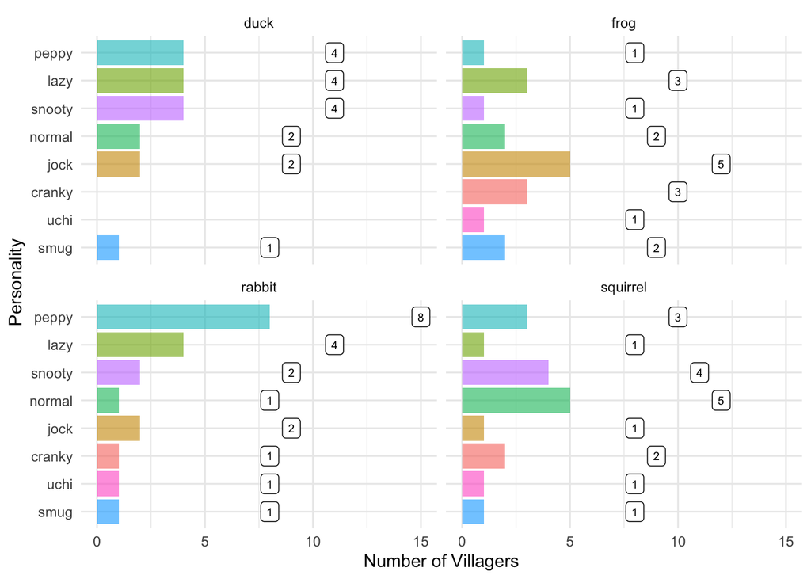

```r
villagers_most_common = villagers %>%
  filter(species %in% c("rabbit","squirrel","frog","duck")) %>%
  group_by(species) %>%
  count(personality) %>%
  arrange(desc(n)) %>%
  ggplot(aes(x = fct_reorder(personality, n), y = n))+
  geom_col(aes(fill = personality), alpha = 0.6)+
  labs(x = "Personality", y = "Number of Villagers")+
  geom_label(aes(label = n), size = 2.5, nudge_y = 7) +
  theme_minimal()+
  theme(legend.position = "none")+
  coord_flip()+
  facet_wrap(~species)

villagers_most_common
```

Based off of these graphs, it looks like the type of personality each villager has is based off of what type of animal they are and is either completely random or relates to the stereotype that an animal typically has in real life. For example, the cat sterotype of being more snooty or peppy, or the rabbit sterotype of being more peppy/energetic.

## Critic and User Reviews

Since many people are playing Animal Crossing, lets take a look to see what their opinions are and compare them to what critics think.

### Anlayzing the Reviews

With the critic and user reviews, we can analyze text data using sentiment analysis to determine whether a review was positive or negative.

**Critic Reviews**

```r
critic_reviews_tidy = critic %>%
  unnest_tokens(output = word, input = text)

critic_sentiment = critic_reviews_tidy %>%
  inner_join(get_sentiments("bing"), by = c("word" = "word"))

critic_sentiment
```

```
## # A tibble: 466 x 5
##    grade publication     date       word        sentiment
##    <dbl> <chr>           <date>     <chr>       <chr>
##  1   100 Pocket Gamer UK 2020-03-16 like        positive
##  2   100 Pocket Gamer UK 2020-03-16 tension     negative
##  3   100 Pocket Gamer UK 2020-03-16 warmth      positive
##  4   100 Pocket Gamer UK 2020-03-16 comfort     positive
##  5   100 Forbes          2020-03-16 overwhelmed negative
##  6   100 Forbes          2020-03-16 stuck       negative
##  7   100 Telegraph       2020-03-16 lengthy     negative
##  8   100 Telegraph       2020-03-16 suffice     positive
##  9   100 Telegraph       2020-03-16 clearly     positive
## 10   100 Telegraph       2020-03-16 worked      positive
## # … with 456 more rows
```

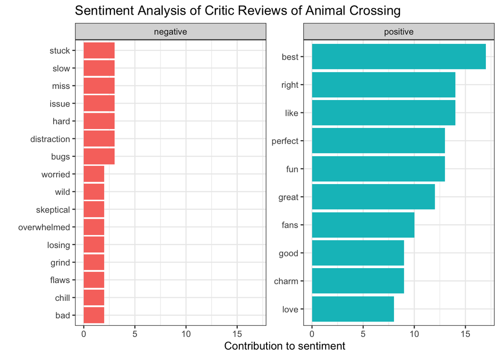

```r
sentiment_counts = critic_sentiment %>%
  count(word, sentiment, sort = TRUE)
sentiment_counts %>%
  group_by(sentiment) %>%
  top_n(10, wt = n) %>%
  ggplot(aes(x = fct_reorder(word, n), y = n,
             fill = sentiment)) +
  geom_col() +
  facet_wrap( ~ sentiment, scales = "free_y") +
  labs(x = "", y = "Contribution to sentiment",
       title = "Sentiment Analysis of Critic Reviews of Animal Crossing") +
  theme_bw() +
  theme(legend.position = "none") +
  coord_flip()
```

Based off of these graphs, it appears as though there are a lot of positive reviews from the critics.

**User Reviews**

```r
user_reviews_tidy = user_reviews %>%
  unnest_tokens(output = word, input = text)

user_sentiment = user_reviews_tidy %>%
  inner_join(get_sentiments("bing"), by = c("word" = "word"))

user_sentiment
```

```
## # A tibble: 23,922 x 5
##    grade user_name date       word         sentiment
##    <dbl> <chr>     <date>     <chr>        <chr>
##  1     4 mds27272  2020-03-20 sucks        negative
##  2     4 mds27272  2020-03-20 miss         negative
##  3     4 mds27272  2020-03-20 terrible     negative
##  4     4 mds27272  2020-03-20 unacceptable negative
##  5     5 lolo2178  2020-03-20 great        positive
##  6     5 lolo2178  2020-03-20 gorgeous     positive
##  7     5 lolo2178  2020-03-20 ignore       negative
##  8     5 lolo2178  2020-03-20 ruins        negative
##  9     5 lolo2178  2020-03-20 limits       negative
## 10     5 lolo2178  2020-03-20 enjoy        positive
## # … with 23,912 more rows
```

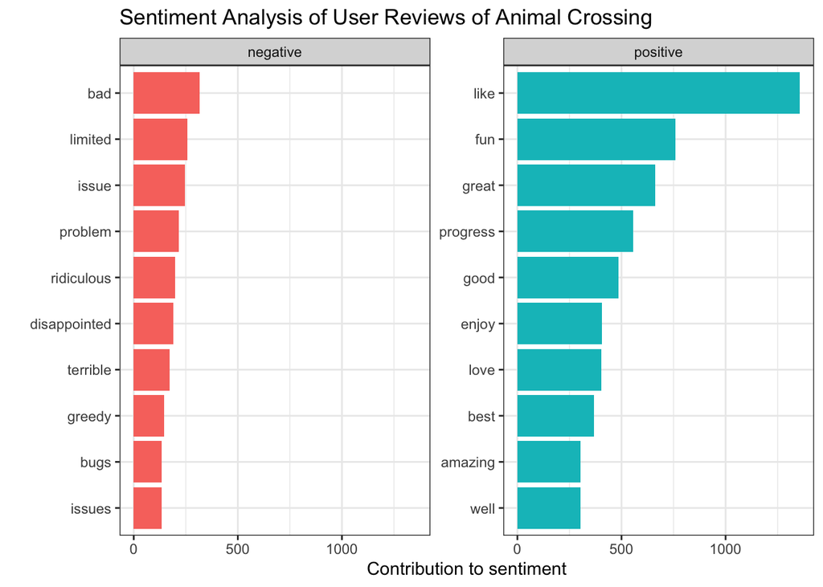

```r
sentiment_counts = user_sentiment %>%
  count(word, sentiment, sort = TRUE)
sentiment_counts %>%
  group_by(sentiment) %>%
  top_n(10, wt = n) %>%
  ggplot(aes(x = fct_reorder(word, n), y = n,
             fill = sentiment)) +
  geom_col() +
  facet_wrap( ~ sentiment, scales = "free_y") +
  labs(x = "", y = "Contribution to sentiment",
       title = "Sentiment Analysis of User Reviews of Animal Crossing") +
  theme_bw() +
  theme(legend.position = "none") +
  coord_flip()
```

Looking at these graphs, it also appears as though users have some good things to say about the game, but also slightly more negative compared to the critics.

### Comparing the Ratings

Now that we have a good idea of what kind of reviews the users and critics gave, let’s take a look at the actual rating numbers.

**Average User Rating**

Here are the average user ratings based on a score out of 10:

```r
user_reviews %>%
  summarize(mean_rating = mean(grade, na.rm = TRUE))
```

```
## # A tibble: 1 x 1
##   mean_rating
##         <dbl>
## 1        4.22
```

Hmm, it appears as though some people are not too happy about the game despite the positive reviews. Let’s take a look as to why that may be later. For now, let’s see how the critics rated the game.

**Average Critic Rating**

Here are the average critic ratings based on a score out of 100:

```r
critic %>%
  summarize(mean_rating = mean(grade, na.rm = TRUE))
```

```
## # A tibble: 1 x 1
##   mean_rating
##         <dbl>
## 1        90.6
```

Now that seems more like it! Looks like the critics gave a far better rating of the game compared to users.

**Comparing the Ratings**

It appears as though users are not too happy with the game compared to the critics. To put them on the same scale, user ratings would be an average of 42/100 while critic ratings are 90.6/100. Despite the positive sentiment that appears in the user reviews, they have a lower average score. A good explanation of that would be the wave of new players to the game. While reviewing the comments, many of them complain about the one island per console situation. For those who don’t know, animal crossing is meant to be a single player game in which there is only one world per console/device. Anyone who would want to make another account would have to share the same island or if you wanted to own your own island you would need another device. This has always been the way of Animal Crosing and old players of the game (who have played older versions of Animal Crossing) already know this. However, due to the hype that Animal Crossing: New Horizons recieved, it attracted a lot of new players (especially during the pandemic). Unfortunately, new players learned the hard way that they can only have one island per console and a lot of people, especially parents, are not happy with that…but it is what it is. *Animal Crossing is a great game, some people are just salty*

## Final Thoughts

Animal Crossing: New Horizons is a step up from any other edition of the game by far. In this edition, players have the ability to terraform and shape the island in any way that they want, they have access to more furniture, they can craft custom recipes for items, and overall have a lot of freedom to do what they want! With that being said, this dataset is a sample of what the game play is like. As seen from the long list of items and how cheap or expensive furniture is (that players can either buy or sell), or from the long list of different villagers/personalities that players can meet, there is a lot to do in the game!

However, as the reviews show…while critics love the game it appears as though many users do not. The graphs that we created show the positive sentiment in many reviews, but our comparison of the average ratings showed that despite the positive sentiment in user reviews, the average grade says otherwise (the reason for this has already been explained). On the other hand, we showed that there was a lot of positive sentiment in the critic reviews and the average rating followed through :). Hopefully, the analysis from this blog made you interested in playing Animal Crossing, but if not, hopefully it sparked a little bit of joy!

Thanks for reading!